# Der Effekt von Earnings-Conference Calls am Aktienmarkt

# Motivation

Earnings Conference Calls sind zentrale Informationsereignisse in Finanzmärkten. Hier kommuniziert das Management direkt mit Investoren und Analysten über die aktuelle Geschäftslage und Zukunftsaussichten. Die finanzwirtschaftliche Forschung zeigt, dass diese Calls erhebliche Kursbewegungen auslösen können - doch die zugrundeliegenden Mechanismen sind noch nicht vollständig verstanden.

Während traditionelle Finanztheorie von effizienten Märkten ausgeht, die alle verfügbaren Informationen sofort verarbeiten, zeigen empirische Studien, dass die Art der Kommunikation und das Sentiment der Aussagen eigenständige Erklärungskraft für Aktienkursreaktionen besitzen. Diese Erkenntnisse haben direkte praktische Relevanz: Banken nutzen Sentiment-Analysen für algorithmische Handelsstrategien, Hedge Fonds entwickeln systematische Ansätze zur Textauswertung, und Asset Manager integrieren qualitative Informationen in ihre Bewertungsmodelle.

In diesem Projekt kombinieren Sie Event Studies - eine etablierte Methode der empirischen Finanzforschung zur Messung von Informationseffekten - mit modernen Large Language Models zur systematischen Textanalyse. Sie untersuchen, ob und wie sich qualitative Aussagen des Managements in quantifizierbaren Marktreaktionen niederschlagen, und lernen dabei sowohl die methodischen Grundlagen der Kausalitätsidentifikation als auch den praktischen Umgang mit KI-gestützten Finanzanalysen kennen.

# Event-Study-Methodik und theoretische Diskussion

1. Lesen Sie das Kapitel [“Event Studies” in Huntington-Klein (2021)](https://theeffectbook.net/ch-EventStudies.html) und beantworten Sie die folgenden Fragen dazu:

Kann eine Eventstudie helfen, den kausalen Effekt eines Earnings Conference Calls auf die Aktienrendite eines Unternehmens zu identifizieren? Gehen Sie bei der Beantwortung dieser Frage insbesondere auf die nachfolgenden Punkte ein:

- Welche Art von Variation nutzt eine Eventstudie zur Identifikation des Effekts?
- Welche Voraussetzung(en) müssen erfüllt sein, damit die Eventstudie eine gültige Kausalschätzung liefert?
  - Was bedeutet das “Joint-Test Problem” in diesem Kontext?

**Kann eine Eventstudie helfen, den kausalen Effekt eines Earnings Conference Calls auf die Aktienrendite eines Unternehmens zu identifizieren?**  
Ja, eine Eventstudie kann dazu beitragen, den kausalen Effekt eines Earnings Conference Calls auf die Aktienrendite eines Unternehmens zu identifizieren, aber nur unter strengen Annahmen. Das Hauptziel ist es, die “anormalen Renditen” zu isolieren – das sind die Renditen, die nicht durch normale Marktbewegungen oder unternehmensspezifische Faktoren erklärt werden können, sondern direkt auf das Ereignis zurückzuführen sind. Die Eventstudie misst die Wirkung einer “Behandlung” (hier: der Earnings Call) auf das untersuchte Wertpapier, indem sie die Reaktion isoliert und von anderen Einflüssen bereinigt.

**Welche Art von Variation nutzt eine Eventstudie zur Identifikation des Effekts?**  
Eine Eventstudie nutzt die zeitliche Variation des Ereignisses, um den Effekt zu identifizieren. Sie beobachtet die Aktienrendite eines Unternehmens im Ereignisfenster um den Zeitpunkt des Earnings Conference Calls. Die Annahme ist, dass alle anderen Informationen, die die Rendite beeinflussen könnten, entweder im Normalfall absorbiert werden (und so “normale” Renditen schätzbar sind) oder konstant sind bzw. keinen Einfluss haben. Die Eventstudie versucht, die Differenz der tatsächlichen Rendite zur erwarteten “Normalrendite” im Ereignisfenster als den Effekt des Earnings Calls zu interpretieren. Die Identifikation basiert somit auf der plötzlichen und unerwarteten Änderung der Information zum Zeitpunkt des Ereignisses, die sich in den Aktienkursen niederschlägt.

**Welche Voraussetzung(en) müssen erfüllt sein, damit die Eventstudie eine gültige Kausalschätzung liefert?**  
Exogenität des Ereignisses (keine Störereignisse): Dies ist die wichtigste Bedingung für kausale Inferenz. Es dürfen keine anderen relevanten Informationen oder Ereignisse gleichzeitig mit dem Earnings Conference Call bekannt werden, die ebenfalls die Aktienrendite beeinflussen könnten. Der Earnings Call muss das einzige neue, informationsrelevante Ereignis im betrachteten Fenster sein.  
Effiziente Märkte (semi-starke Form): Die Informationen aus dem Earnings Call müssen vom Markt sofort und vollständig verarbeitet werden. Eine verzögerte oder unvollständige Informationsverarbeitung würde die Messung verzerren.  
Korrekte Spezifikation des Normalrenditemodells: Das Modell zur Schätzung der “normalen” Rendite (die Rendite, die ohne das Ereignis erwartet worden wäre) muss korrekt sein. Fehler im Modell können zu verzerrten abnormalen Renditen und damit zu falschen Kausalitätszuschreibungen führen.  
Keine Selektionsverzerrung: Die untersuchten Unternehmen oder die Art der Calls dürfen sich nicht systematisch von anderen Unternehmen oder Calls unterscheiden, was die Ergebnisse beeinflussen könnte.  
In der Praxis ist die Exogenität (Vermeidung simultaner Störereignisse) oft die größte Herausforderung.

**Was bedeutet das “Joint-Test Problem” in diesem Kontext?**  
Das “Joint-Test Problem” (oder “Joint Hypothesis Problem”) bezieht sich auf die grundlegende Schwierigkeit, in Event Studies die Hypothese über die Markteffizienz von der Hypothese über die spezifische Reaktion auf ein Ereignis zu trennen. Wenn eine Eventstudie signifikante anomale Renditen identifiziert, testet sie gemeinsam (jointly) zwei Hypothesen:  
Die Hypothese, dass die verwendeten Modelle zur Schätzung der “normalen” Renditen korrekt sind (d.h., das zugrunde liegende Finanzmarktmodell ist gültig).  
Die Hypothese, dass das Ereignis tatsächlich eine Wirkung auf die Aktienrendite hat.  
Das Problem ist, dass man bei einem signifikanten Ergebnis nicht eindeutig sagen kann, ob dieser Effekt auf eine tatsächliche Marktreaktion auf den Call zurückzuführen ist oder ob das Ergebnis lediglich eine Fehlklassifikation oder eine unzureichende Spezifikation des Marktmodells zur Folge hat. Man testet also nie nur die Wirkung des Ereignisses, sondern immer auch die Gültigkeit des verwendeten Finanzmarktmodells. Dies macht eine rein kausale Schlussfolgerung schwierig, da das Ergebnis auch auf ein möglicherweise fehlerhaftes Modell der Erwartungsbildung des Marktes zurückgeführt werden könnte.

# Daten und Datenaufbereitung

## Finanzmarktkennzahlen

2. Sie sollten in einem ersten Schritt Finanzkennzahlen aus Datastream herunterladen. Insbesondere sollten Sie den Return Index (RI) und die Total Assets (WC02999) für alle Firmen im Euro Stoxx 600 Technology Index ( wir haben Ihnen die RIC Kürzel in der Readme bereitgestellt ) vom 01.01.2020 bis heute extrahieren.

Bitte laden Sie für den Return Index tägliche Daten herunter und für die Total Assets Quartalsdaten. Weiterhin sollten Sie den Total Return Index (RI) des Euro Stoxx 600 (RIC = .STOXX) herunterladen (auch tägliche Daten). Bitte achten Sie darauf alle Daten **in Euro** herunterzuladen.

Achten Sie darauf die RIC als eindeutige Identifikationskennung in ihren Datensatz aufzunehmen.

Das Institut für Finanzwirtschaft der Universität Ulm hat einen ausführlichen [Guide zu Datastream](https://www.uni-ulm.de/fileadmin/website_uni_ulm/allgemein/Update_Introduction_Datastream_May_2025.pdf) erstellt, der Ihnen beim Download der Daten sicherlich helfen kann.

Die Universität Ulm stellt für den Download Remote-PCs zur Verfügung, auf die Sie sich von daheim aus einloggen können. Bitte buchen Sie sich hier einen Slot um Zugriff auf diese PCs zu erhalten: https://www.uni-ulm.de/mawi/iof/lehre/proposals-for-theses/datastream-and-workspace/

Sie sollten ihre Daten in Excel herunterladen und in ihrem Projekt im Unterordner `data` abspeichern.

*Hinweis 1:* Es empfiehlt sich zwei Tabellenblätter im Excel File anzulegen, eines für die täglichen Daten und eines für die Quartalsdaten

*Hinweis 2:* Datastream ist eine Datenbank, die Kennzahlen zur Finanzlage von börsennotierten Unternehmen weltweit beinhaltet. Die Lizenzen zu Datastream an der Universität Ulm werden von der Studienkommission Wirtschaftswissenschaften und der LBBW bezahlt und die Datenbank steht allen WiWi-Studierenden frei zur Verfügung. [Nähere Informationen zu Datastream finden Sie hier](https://www.uni-ulm.de/mawi/iof/lehre/proposals-for-theses/datastream-and-workspace/) (Bitte beachten: Sie müssen im Uninetz (z.B. über VPN) eingeloggt sein um die Informationen zu sehen und um sich auf die Remote-PCs loggen zu können).

*Hinweis 3:* Bei den Total Assets müssen Sie immer das Enddatum des vorherigen Jahres nehmen für den Download, d.h. Start Date wäre 31.12.2019

3. Lesen Sie die Excel Datei, welche Sie in Aufgabe 2 erstellt haben, in R ein. Achten Sie darauf, dass diese Daten tidy und richtig formatiert sind. Joinen Sie die täglichen Daten mit den Quartalsdaten für die relevanten Firmen. Die Quartalsdaten zählen für das komplette Quartal zu dem diese hinzugemerged wurden.

Setzen Sie sich mit den Aktienkursen auseinander und beantworten folgende Fragen: - Sie wollen in Aufgabe 4 *Renditen* berechnen, warum sollten Sie Daten zum “Total Return Index” und nicht dem “Price” oder “Unadjusted Price” herunterladen? Schauen Sie sich zur Klärung dieser Frage den [Guide der Uni Ulm zu Datastream](https://www.uni-ulm.de/fileadmin/website_uni_ulm/allgemein/Update_Introduction_Datastream_May_2025.pdf) genauer an. Diesen Guide sollten sie auch für den Download der Daten heranziehen.

*Hinweis:* In dem tidy Datensatz sollten Sie eine Spalte mit dem Unternehmensidentifier (RIC), eine mit dem Datum und eine mit der Variablen (RI bzw. Total Assets) haben

Der Total Return Index (RI) ist für die Renditeberechnung unerlässlich, da er, im Gegensatz zum reinen Preis oder Unadjusted Price, nicht nur die Kursentwicklung, sondern auch Dividendenzahlungen und andere Kapitalmaßnahmen (wie Aktiensplits) berücksichtigt. Der RI stellt sicher, dass alle Erträge, die ein Investor aus einer Anlage generiert (als wären Dividenden reinvestiert worden), korrekt abgebildet werden. Würde man nur den reinen Kurs betrachten, würde die tatsächliche Performance systematisch unterschätzt, da Dividenden und Anpassungen durch Kapitalmaßnahmen ignoriert würden. Der Uni Ulm Guide zu Datastream bestätigt, dass der Total Return Index der Standard für die Abbildung der Gesamtrendite ist und somit für valide finanzwirtschaftliche Renditeberechnungen unerlässlich.

## Renditen berechnen

4. In ihrem Datastream-Datensatz, welchen Sie in Aufgabe 2 bereits eingelesen und in Aufgabe 3 bearbeitet haben, sind die *Total Return Indices* (RI) der größten Unternehmen aus der Tech-Branche in Europa enthalten, sowie der *Total Return Indix* des Euro Stoxx 600. Der Euro Stoxx 600 ist ein großer, diversifizierter Aktienindex in Europa in dem die 600 größten Unternehmen gelistet sind. Sie sollten den Euro Stoxx 600 als Benchmark ( Rendite des Marktes ) für ihre betrachteten Unternehmen verwenden. Bitte berechnen Sie in dieser Aufgabe die Tagesrenditen aller Einzelunternehmen als:

$$\begin{equation}
Rendite_{i,t} = \frac{RI_{i,t} - RI_{i,t-1}}{RI_{i,t-1}}
\end{equation}$$

mit i = {jedes Einzelunternehmen im Datensatz} und t = {Tag}

und des Euro Stoxx 600 als:

$$\begin{equation}
Rendite_{m,t} = \frac{RI_{m,t} - RI_{m,t-1}}{RI_{m,t-1}}
\end{equation}$$

mit m = {Euro Stoxx 600} und t = {Tag}

Prüfen Sie auf NA in den Anfangszeilen und entfernen Sie diese.

Speichern Sie die Renditen der jeweiligen Unternehmen in einer neuen Variable `Rendite` ab und die Rendite des Euro Stoxx 600 als `Marktrendite`.

5. In Aufgabe 1 hatten Sie sich bereits mit der Event-Study Methodik beschäftigt, welche Sie im weiteren Verlauf des Projektes anwenden sollen. Ein erster Schritt ist es, sogenannte *Abnormale Renditen* zu berechnen. Dies sollten Sie in dieser Aufgabe mit dem sogenannten Market-adjusted returns model tun. Bitte ziehen Sie dafür die Rendite des Marktindex von der Rendite des einzelnen Unternehmens pro Tag ab.

$$\begin{equation}
AbnormaleRendite_t = Rendite_{i,t} - Rendite_{m,t}
\end{equation}$$

Beantworten Sie dazu folgende Frage:

- Warum ist es nötig die Marktrendite ( $Rendite_{m,t}$ ) von der Rendite der Einzelaktien abzuziehen? Nutzen Sie ihre Erkenntnisse aus Aufgabe 1 zur Beantwortung dieser Frage.

Das Abziehen der Marktrendite von der Einzelaktienrendite ist ein Kernschritt der Event-Study-Methodik. Dies dient dazu, den kausalen Effekt eines spezifischen Ereignisses (wie eines Earnings Calls) auf die Aktienrendite zu isolieren. Aktienrenditen werden maßgeblich von allgemeinen Marktbewegungen beeinflusst, die nichts mit dem jeweiligen Unternehmen zu tun haben. Durch das Subtrahieren der Marktrendite wird dieser marktweite Einfluss herausgerechnet.  
Dadurch soll die verbleibende abnormale Rendite ausschließlich den Anteil widerspiegeln, der auf die firmenspezifische Information des Ereignisses zurückzuführen ist. Dies ist entscheidend, um die in Aufgabe 1 besprochene Voraussetzung der Exogenität des Ereignisses zu erfüllen und eine validere Kausalschätzung zu erhalten, indem “Störgeräusche” des Gesamtmarktes kontrolliert werden.

## Earnings Call-Transkripte von LSEG Workspace einlesen

Die Basis für alle weiteren Analysen sind die Abnormalen Renditen der einzelner Unternehmen, die Sie in den vorherigen Aufgaben berechnet haben. Jedoch benötigen Sie nun noch ein Event, dessen Effekt Sie im Rahmen der Eventstudie analysieren möchten. Hier kommen die bereits in der Motivation erwähnten Earnings-Conference-Calls ins Spiel, die Sie im weiteren Verlauf des Projekts näher analysieren sollten. Die Earnings Conference Calls finden für große Unternehmen in der Regel quartalsweise statt. Manche Unternehmen halten jedoch auch nur halbjährliche Earnings Conference Calls ab und andere verzichten ganz darauf.

6. Wir haben Ihnen die Earnings Conference Calls aus LSEG Workspace für alle Firmen aus dem Euro Stoxx 600 Technology Sektor ab 2020 bis zum aktuellen Rand heruntergeladen und diese unter `data/transcripts.zip` bereitgestellt. Lesen Sie die Dateien in R ein. Ihr Datensatz sollte für jedes Transkript das RIC-Kürzel, Datum und den Text des Transkripts beinhalten, dies können Sie aus dem Namen der Datei extrahieren.

*Hinweis:* Das RIC Kürzel finden Sie im Namen der Datei (Beispiel: “2020-Jan-28-SAPG.DE-140242583050-Transcript.txt” -> “Datum-RIC-Nummer-Transcript.txt”)

Die Earnings Conference Calls laufen immer gleich ab: Zuerst spricht der CEO und meist CFO über die aktuellen Entwicklungen am Markt und wie das Unternehmen aktuell steht. Weiterhin werden Einschätzungen für die Zukunft angesprochen. Im zweiten Teil, der Q&A Sektion, dürfen Analysten Fragen an das Management stellen. Dieser Teil ist meist informativer als die vorbereiteten Statements des Managements, da die Fragen nicht vorher abgesprochen werden und das Management spontane Antworten bereithalten muss.

Sie sollen sich in diesem Projekt auf den zweiten Teil, d.h. die Q&A Section in den Earnings Conference Calls konzentrieren.

7. Analysieren Sie im ersten Schritt die Earnings Conference Calls indem Sie einige davon überfliegen. Schauen Sie explizit nach Hinweisen, ob und wie die Q&A Sektion im Text von den anderen Inhalten abgetrennt ist. Anschließend sollten Sie diese Q&A Sektion in den Earnings Conference Calls in R extrahieren, da Sie nur diese Sektion in den späteren Aufgaben analysieren sollen.

Da es vorteilhaft für ihre weitergehenden Analysen ist möglichst kompakte Texte ohne Redundanzen zu haben, sollten Sie zusätzlich die Definitionen und Disclaimer Sektion am Ende des Earnings Calls entfernen.

*Hinweis 1:* Der Anteil der Q&A Sektion an der Gesamtkonversation liegt in der Regel unter 80%. Für manche Earnings Conference Calls ist dieser Anteil höher, aber hier würde ich empfehlen nachzuschauen, ob Sie die Q&A Sektion richtig extrahiert haben. Manchmal gibt es keine Q&A Sektion, dann sollte dort auch kein Text extrahiert werden.

*Hinweis 2:* Nutzen Sie das Paket `stringr` um Textmanipulationen vorzunehmen. In diesem [Cheatsheet](https://rstudio.github.io/cheatsheets/strings.pdf) sehen Sie die Hauptanwendungen inkl. regulärer Ausdrücke, welche wichtig sind um mit Texten zu arbeiten.

8. Stellen Sie in einer Grafik anschaulich dar, wie viele Worte in einem typischen Earnings Conference Call verwendet werden und wie viel davon die Q&A Sektion einnimmt.

Beschreiben Sie ihre Grafik.

*Hinweis:* Eventuell wollen Sie hier die Verteilungen zeigen o.ä.? Entscheiden Sie selbst, welche Grafik Sie produzieren.

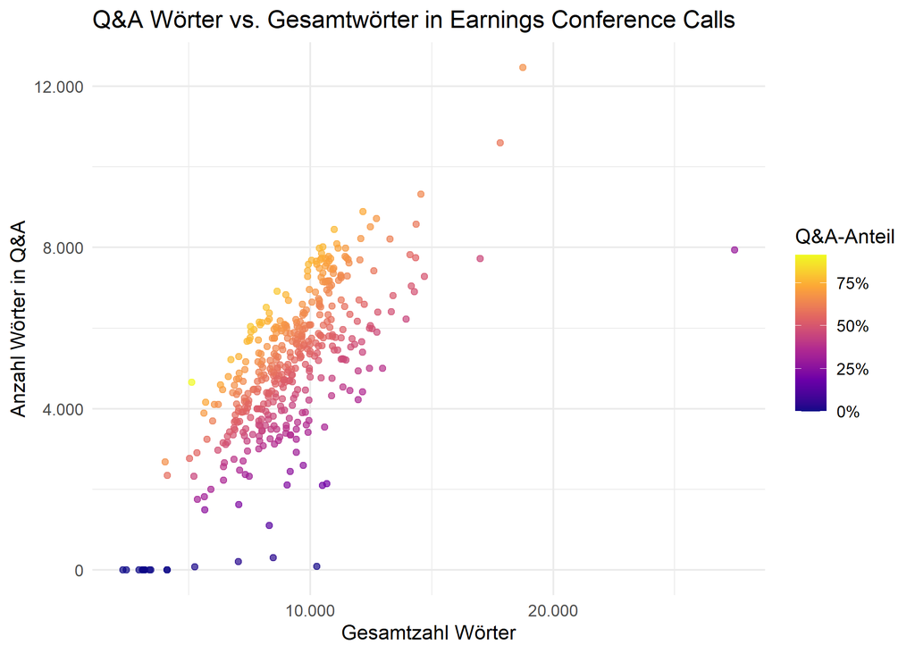

Der vorliegende Plot stellt die Beziehung zwischen der Gesamtzahl der Wörter in einem Earnings Conference Call (ECC) und der Anzahl der Wörter, die spezifisch in der Q&A-Sektion dieses Calls verwendet werden, dar. Dabei repräsentiert die X-Achse die Gesamtzahl der Wörter im ECC, während die Y-Achse die Anzahl der Wörter in der Q&A-Sektion abbildet. Die Farbskala des Plots visualisiert zusätzlich das Verhältnis, also den Anteil der Q&A-Wörter zur Gesamtzahl der Wörter, und wird als “Q&A-Anteil” bezeichnet.

In der Interpretation dieses Plots fällt auf, dass Punkte, die nahe an der Diagonalen liegen, Calls kennzeichnen, bei denen der Q&A-Anteil sehr hoch ist, teilweise nahe 100%. Dies deutet darauf hin, dass in diesen Fällen ein Großteil des gesamten Transkripts der Fragerunde gewidmet war. Des Weiteren ist ersichtlich, dass viele der analysierten Calls einen Q&A-Anteil unter 80% aufweisen, was als typisch für Earnings Conference Calls gelten kann. Es gibt jedoch auch einzelne Calls, die sehr hohe Q&A-Anteile von nahezu 100% zeigen. Solche Ausprägungen könnten auf besonders ausführliche Q&A-Abschnitte oder andere Spezifika des jeweiligen Calls hinweisen. Zusammenfassend liefert der Plot einen guten Überblick über die Verteilung sowohl der Länge als auch des relativen Anteils der Q&A-Sektionen innerhalb der gesamten Earnings Conference Calls.

## Themenkategorien und Sentiment-Scores

Nachdem Sie nun die Earnings Conference Calls in R eingelesen und einen ersten Eindruck von deren Inhalt erhalten haben sollten Sie diese mit einem LLM (konkret mit Google Gemini) analysieren. Dafür sollten Sie einen Zero-Shot Prompt erstellen und mit Hilfe dieses Prompts die Aussage der Q&A Sektionen der Earnings Conference Calls analysieren.

9. Entwickeln Sie einen Zero-Shot Prompt für ein Large Language Model (LLM), der Earnings Conference Call Transcripts analysiert und strukturierte Sentiment-Bewertungen ausgibt. Bitte beachten Sie dabei folgende Punkte:

Zielkategorien:

- Unternehmensperformance (Finanzlage, Wachstumschancen, Unternehmensrisiken)
- Marktumfeld (Branche, Wettbewerb, externe Faktoren)

Output-Format:

- JSON-Struktur mit Sentiment-Scores von -1 (sehr negativ) bis +1 (sehr positiv)
- Keine zusätzlichen Erklärungen oder Markdown-Formatierung

Sie sollten in ihrem Prompt nach einem JSON Output verlangen (strukturiertes Format), welchen Sie mit dem Paket `jsonlite` gut in R verarbeiten können.

*Hinweis 1:* Im Anhang ist eine Erklärung für die Unterschiede zwischen einem Zero-Shot Prompt, einem One-Shot Prompt und einem Few-Shot Prompt

*Hinweis 2:* Wir haben Ihnen ein [Tutorial zusammengestellt](https://projektkurs-data-science-ulm2425.netlify.app/tutorials/zero-prompting), welches das Prompting an einem Beispiel zeigt.

*Prompt:*

```
## Bitte analysiere den folgenden Text aus der Q&A-Sektion eines Earnings Conference Calls. Nutze dabei eine geringe Kreativität ( temperature = 0.2). Gib anschließend eine strukturierte Sentiment-Bewertung für die beiden Kategorien Unternehmensperformance und Marktumfeld aus.
##
## Bewerte jede Kategorie mit einem Sentiment-Score von -1 (sehr negativ) bis +1 (sehr positiv).
##
## Gib ausschließlich ein JSON-Objekt zurück, ohne Text, ohne Einleitung, ohne Erklärung und ohne Markdown-Formatierung, sodass die Antwort direkt in R mit fromJson eingelesen werden kann:
##
## {
##   "Unternehmensperformance": <Sentiment-Score>,
##   "Marktumfeld": <Sentiment-Score>
## }
##
## Text zur Analyse:
## %s
```

10. Im nächsten Schritt sollten Sie sich in das Paket [`ellmer`](https://ellmer.tidyverse.org/) einarbeiten. Durch `ellmer` erhalten Sie Zugriff auf alle gängigen LLMs mittels R über einen API Zugang. Wir haben ihnen für dieses Projekt ein Google Konto pro Gruppe erstellt und den API Schlüssel für jede Gruppe in das dazugehörige Repo (Readme) gepushed.
- Lesen Sie sich in das [`ellmer`](https://ellmer.tidyverse.org/) Paket ein und wie Sie den API Schlüssel für Google Gemini in ihrer .Renviron Datei hinterlegen können
- Untersuchen Sie die unterschiedlichen Modelle, die Google zur Verfügung stellt und deren Ratelimits: https://ai.google.dev/gemini-api/docs/models?hl=de

Bitte beantworten Sie folgende Fragen:

- Was sind die Vorteile/Nachteile der einzelnen Google Modelle?
- Welches (kostenlose) Modell würden Sie für ihre aktuellen Analysen bevorzugt einsetzen? Begründen Sie!
- Welche Möglichkeiten haben Sie, nicht in die Ratelimits zu kommen?
- In `ellmer` können Sie mittels dem [`params()`](https://www.tidyverse.org/blog/2025/05/ellmer-0-2-0/#parameters) Parameter auch die Temperatur ihres Modells einstellen. Was ist mit der Temperatur gemeint und was sind die Vorteile/Nachteile einer niedrigen Temperatur?

**Was sind die Vorteile/Nachteile der einzelnen Google Modelle?**  
Betrachtet man die von Google angebotenen Gemini-Modelle im Kontext der aktuellen Analyse, so bieten diese unterschiedliche Vor- und Nachteile. Das Gemini 2.5 Flash Modell, als die neueste Inkarnation der “Flash”-Reihe, ist für extrem hohe Volumen und schnelle Ausführung zu geringen Kosten optimiert. Es bietet voraussichtlich verbesserte Fähigkeiten in Bezug auf Geschwindigkeit und Effizienz bei gleichzeitig großem Kontextfenster, ist jedoch bei sehr komplexen Schlussfolgerungen möglicherweise weniger präzise als größere Modelle. Das Gemini 2.5 Pro Modell hingegen ist für komplexere und anspruchsvollere Aufgaben konzipiert, die eine höhere Inferenzqualität erfordern und ebenfalls über ein sehr großes Kontextfenster verfügen. Dies geht jedoch voraussichtlich mit höheren Kosten und einer langsameren Verarbeitung pro Anfrage einher. Das ältere Gemini 1.5 Pro Modell bietet ein ausgewogenes Verhältnis von Leistung und Fähigkeiten für eine breitere Palette komplexerer Aufgaben und verfügt ebenfalls über ein 1-Million-Token-Kontextfenster, ist aber im Vergleich zu den 2.5-Modellen weniger leistungsfähig und teurer.

**Welches (kostenlose) Modell würden Sie für ihre aktuellen Analysen bevorzugt einsetzen?**  
Für die Sentiment-Analyse von 429 Earnings Conference Call Transkripten würde Google Gemini 2.5 Flash bevorzugt eingesetzt. Die Begründung hierfür liegt in seiner Optimierung für hohe Volumen, seiner Geschwindigkeit und Kosteneffizienz, welche bei der Verarbeitung einer so großen Menge an Transkripten entscheidend sind. Obwohl Gemini 2.5 Pro potenziell nuanciertere Ergebnisse liefern könnte, ist für die breite Sentiment-Analyse über viele Dokumente hinweg die Effizienz und das Kosten-Nutzen-Verhältnis des Flash-Modells in der Regel überlegen.

**Welche Möglichkeiten haben Sie, nicht in die Ratelimits zu kommen?**  
Ein wichtiger Aspekt bei der Nutzung der Google-API sind die gesetzten Ratelimits, die die Anzahl und Häufigkeit der Anfragen beschränken. Um diese Limits nicht zu überschreiten, empfiehlt es sich, Anfragen so effizient wie möglich zu gestalten, beispielsweise durch kurze und präzise Prompts, die wenig Tokens verbrauchen. Ebenso hilfreich ist das Zwischenspeichern (Caching) von Ergebnissen, um wiederholte API-Anfragen zu vermeiden. Große Anfragen sollten in kleinere Teile aufgeteilt werden, und ein verantwortungsvoller Umgang mit der API-Nutzung durch Monitoring und Steuerung der Anfragefrequenz ist ratsam.

**Was ist mit der Temperatur gemeint und was sind die Vorteile/Nachteile einer niedrigen Temperatur?**  
Ein weiterer Parameter, den man in ellmer über die Funktion params() steuern kann, ist die sogenannte Temperatur. Diese beeinflusst, wie kreativ oder zufällig die Antworten des Modells ausfallen. Eine niedrige Temperatur (beispielsweise zwischen 0.1 und 0.3) führt zu konsistenten, deterministischen und vorhersehbaren Antworten, die besonders bei faktenbasierten oder analytischen Aufgaben von Vorteil sind. Nachteilig kann sein, dass die Antworten dadurch monoton oder weniger abwechslungsreich wirken. Höhere Temperaturen (zum Beispiel ab 0.7) erlauben kreativere und vielfältigere Ausgaben, bergen aber das Risiko, dass die Antworten ungenauer oder spekulativer werden. Für unser Projekt halten wir eine niedrige bis mittlere Temperatur um 0.2 bis 0.3 für optimal, um verlässliche und nachvollziehbare Ergebnisse zu erzielen.

11. Nutzen Sie ihren in Aufgabe 9 erstellten Prompt mit dem `ellmer` Paket und ihrem Google API-Key um alle 431 Earnings Conference Call Transkripte zu analysieren. Nutzen Sie für ihre Analyse das Modell Google Gemini 2.0-flash oder Google Gemini 2.5-flash.

Speichern Sie die Ergebnisse ihrer Analyse in einem strukturierten Tibble ab. Anschließend sollten Sie den Datensatz auch unter `data/sentiment.Rds` abspeichern.

Stellen Sie ihre Ergebnisse in einer Tabelle dar und beschreiben diese kurz:

- Wie ist der Mittelwert, Standardabweichung und Median der Einschätzung bezüglich Unternehmensperformance und Marktumfeld in ihren Earnings Conference Calls?

*Hinweis 1:* Achten Sie darauf nicht bei jedem Knitten die Analyse neu zu starten, sondern setzen Sie den Chunk dieser Aufgabe auf `eval = FALSE` und lassen Sie die Analyse nur einmal durchlaufen und speichern Sie die Ergebnisse ab (und laden diese später um damit weiterarbeiten zu können)

*Hinweis 2:* Achten Sie auf ihre Ratelimits und beanspruchen Sie den API Zugriff nicht zu stark, z.B. durch den Einbau von “sleep”-Zeiten in ihrem Code

Sentiment Scores der Earnings Conference Calls

| Kennzahl | Unternehmensperformance | Marktumfeld |
| --- | --- | --- |
| Mittelwert | 0.731 | 0.241 |
| Standardabweichung | 0.286 | 0.500 |
| Median | 0.800 | 0.400 |

**Beschreibung der Ergebnisse:**

Die Ergebnisse zeigen, dass der Mittelwert für die Einschätzung der Unternehmensperformance bei 0.731 liegt, was auf eine tendenziell positive durchschnittliche Einschätzung über alle analysierten Calls hinweist. Die Standardabweichung von 0.286 ist vergleichsweise gering und deutet darauf hin, dass die individuellen Einschätzungen nicht extrem stark vom Mittelwert abweichen, was eine relativ hohe Konzentration der Meinungen impliziert. Der Median von 0.800 ist höher als der Mittelwert, was eine mögliche leichte Linksschiefe in der Verteilung suggeriert, bei der ein Großteil der Daten auf der höheren Seite des Mittelwerts liegt.

Für das Marktumfeld beträgt der Mittelwert 0.241, was auf eine leicht positive, aber deutlich neutralere durchschnittliche Einschätzung hindeutet als die der Unternehmensperformance. Die Standardabweichung von 0.500 ist im Vergleich zur Unternehmensperformance deutlich höher, was auf eine größere Streuung und somit eine breitere Verteilung der Einschätzungen zum Marktumfeld hinweist; hier gibt es eine größere Varianz in den Meinungen. Der Median von 0.400 ist höher als der Mittelwert, was auch hier auf eine mögliche Linksschiefe in der Verteilung der Marktumfeldeinschätzungen hindeuten könnte.

Zusammenfassend lässt sich festhalten, dass die Unternehmensperformance tendenziell positiver eingeschätzt wird als das allgemeine Marktumfeld. Während die Einschätzungen zur Unternehmensperformance mit einem Mittelwert von 0.731 relativ optimistisch sind und eine geringere Streuung aufweisen (Standardabweichung 0.286), ist die Einschätzung des Marktumfelds mit einem Mittelwert von 0.241 deutlich neutraler und gleichzeitig stärker variierend (Standardabweichung 0.500). Die Mediane bestätigen diese Tendenzen und deuten in beiden Fällen auf eine Konzentration der Werte auf der positiveren Seite des Spektrums hin, wobei insbesondere bei der Unternehmensperformance ein großer Teil der Einschätzungen sehr positiv ausfällt. Die höhere Standardabweichung beim Marktumfeld könnte auf größere Unsicherheit oder divergentere Meinungen bezüglich der allgemeinen Marktbedingungen hindeuten.

Sie haben in der vorherigen Aufgabe die Stimmung bezüglich der Kategorien Unternehmensperformance und Marktperformance in den Earnings Conference Calls bestimmt. Eine Frage wäre, ob sich diese Stimmung über die Zeit hinweg verändert hat. In der folgenden Aufgabe sollen Sie sich die durchschnittliche Stimmung in diesen zwei Kategorien für die einzelnen Jahre in ihrem Datensatz näher anschauen.

12. Erstellen Sie eine geeignete Grafik um die Stimmung *aller Earnings Conference Calls eines Jahres* zu visualisieren. Tragen Sie separat die Stimmung bezüglich Unternehmensperformance und Marktumfeld ab.

Beschreiben Sie ihre Grafik.

Interpretieren Sie diese Grafik, insbesondere im Hinblick auf die gesamtwirtschaftlichen Ereignisse der letzten fünf Jahre. Hätten Sie die Ergebnisse in dieser Art erwartet?

*Hinweis:* Sie sollten sich hier eine sinnvolle Grafik überlegen, welche die Stimmungslage über die Zeit gut darstellt.

[figure not shown]

[figure not shown]

**Beschreibung der Visualisierung:**

Zur Darstellung der Stimmung in Earnings Conference Calls (ECCs) wurden mithilfe eines LLM (Google Gemini 2.5 Flash) Sentiment-Scores in drei Kategorien eingeteilt:

- **Positiv**: Score > +0.1
- **Neutral**: Score zwischen -0.1 und +0.1
- **Negativ**: Score < -0.1

Diese konservative Einteilung reduziert Überinterpretationen kleiner Schwankungen. Die Visualisierung zeigt den prozentualen Anteil der Kategorien je Jahr, getrennt nach **Unternehmensperformance** und **Marktumfeld**. Die Farben sind intuitiv gewählt: Grün für positiv, Orange für neutral und Rot für negativ. Prozentwerte werden nur bei Anteilen ab 3 % angezeigt, um Überlagerungen zu vermeiden.

**Interpretation der Ergebnisse:**

Die Visualisierung zeigt wirtschaftlich nachvollziehbare Entwicklungen: Im Jahr 2020, das stark vom COVID-19-Schock geprägt war, nahm der Anteil negativer Stimmungen insbesondere beim Marktumfeld deutlich zu, während das Unternehmenssentiment vergleichsweise stabil blieb, was auf eine optimistischere Selbsteinschätzung der Firmen hindeutet.

Der Unterschied zwischen Unternehmens- und Marktsentiment könnte die Tendenz der Unternehmen widerspiegeln, ihre Lage positiver darzustellen als es das makroökonomische Umfeld zulässt, was auf eine gewisse Resilienz oder anhaltenden Optimismus schließen lässt.

**Einordnung im Kontext der Eventstudienlogik (vgl. Aufgabe 1):**

Diese Ergebnisse lassen sich gut in die Eventstudienlogik einordnen: Earnings Calls sind wichtige Informationsereignisse, deren Wirkung sich in den Stimmungsschwankungen widerspiegelt. Die schnelle Reaktion des Sentiments auf externe Schocks spricht für eine effiziente Informationsverarbeitung durch den Markt. Gleichzeitig zeigen die Daten die Grenzen kausaler Interpretation in turbulenten Zeiten, in denen externe Einflüsse schwer von spezifischen Eventwirkungen zu trennen sind (Joint-Test-Problem).

**Fazit:**

> **Hinweis:** Prozentwerte in den Balken wurden bewusst nur ab einem Anteil von 3 % angezeigt, um die Lesbarkeit zu verbessern.

# Eventstudie

Um zu evaluieren, ob die Earnings Conference Calls tatsächlich einen Einfluss auf die Aktienkurse der einzelnen Unternehmen hatten können Sie eine sogenannte Eventstudie durchführen, welche Sie bereits in Aufgabe 1 kennen gelernt haben. Bei einer Eventstudie betrachten Sie nur die Zeit (bei uns die Tage) unmittelbar vor oder nach einem Event. In diesem Projekt ist ein Event ein Earnings Conference Call des jeweiligen Unternehmens. Sie sollen in diesem Projekt herausfinden, wie sich über alle Unternehmen hinweg die Earnings Conference Calls auf die Aktienrenditen auswirken.

13. Verbinden Sie den Datensatz über die *Stimmung der Earnings Conference Calls (sentiment.Rds)* zu den einzelnen Unternehmen mit den *abnormalen Renditen* und speichern diesen Datensatz als `gesamtdatensatz` in R ab. Sie können das RIC-Kürzel und Datum für den Join verwenden. Sollte der Earnings Conference Call an keinem Handelstag stattgefunden haben, so joinen Sie bitte mit dem darauffolgenden Handelstag.
- Für die Tage an denen ein Earnings Conference Call stattgefunden hat sollten Sie eine Variable `event` generieren, welche an dem Tag des Calls gleich 0 ist.
- Für die Tage vor dem Earnings Conference Call (Event) sollte die Variable `event` rückwärts zählen (bis zu -5). Für alle Tage nach dem Event sollte die Variable `event` fortgeführt werden (bis +5).
- Erstellen Sie eine Variable `ar_505`, welche die *abnormalen Rendite* von Tag -5 bis +5 **fortlaufend** aufsummiert
- Erstellen Sie eine Variable `car_101`, welche die kumulierte abnormale Rendite im Zeitraum -1 bis +1 um das Event beinhaltet
- Erstellen Sie weiterhin diese sechs neuen Variablen:
  - `negativ_firm` = Wenn die Unternehmensperformance als negativ eingeschätzt wird
  - `neutral_firm` = Wenn die Unternehmensperformance als neutral eingeschätzt wird
  - `positiv_firm` = Wenn die Unternehmensperformance als positiv eingeschätzt wird
  - `negativ_market` = Wenn die Marktperformance als negativ eingeschätzt wird
  - `neutral_market` = Wenn die Marktperformance als neutral eingeschätzt wird
  - `positiv_market` = Wenn die Marktperformance als positiv eingeschätzt wird
- Erstellen Sie Dummy Variablen, die 1 sind für ein bestimmtes Jahr. Bspw. eine Dummyvariable die 2020 heißt und für alle Beobachtungen im Jahr 2020 sollte diese Variable 1 sein, 0 sonst. Tun Sie dies für alle Jahre in ihrem Datensatz

*Hinweis:* Die Funktion cumsum() könnte für diese Aufgabe hilfreich sein

**Kontext und Zielsetzung:**

In dieser Aufgabe verbinden wir die Sentiment-Daten der Earnings Conference Calls mit den abnormalen Renditen der Unternehmen, um die Wirkung der Events auf die Aktienkurse zu untersuchen. Dabei erstellen wir eine Event-Variable, kumulierte Renditen und weitere Dummy-Variablen, die in den folgenden Analysen verwendet werden können.

Der so erzeugte Datensatz verbindet präzise die Sentiment-Einschätzungen der Earnings Calls mit den zugehörigen abnormalen Renditen. Die Event-Variable ermöglicht eine genaue Analyse des Verhaltens der Aktienkurse im Zeitraum von fünf Handelstagen vor bis fünf Handelstagen nach dem Call.

Die kumulierten abnormalen Renditen über das breite Fenster (-5 bis +5 Tage) sowie das engere Fenster (-1 bis +1 Tage) erlauben eine differenzierte Betrachtung der Marktreaktionen. Die Dummy-Variablen für die Stimmungs-Kategorien unterstützen die Untersuchung, ob und wie sich die Marktreaktionen je nach positiver, neutraler oder negativer Stimmung unterscheiden.

Jahresdummies gewährleisten, dass makroökonomische und zeitliche Effekte in den anschließenden Analysen kontrolliert werden können, was die Validität der Ergebnisse erhöht.

**Fazit:**

Mit diesem Gesamtdatensatz wurde eine solide Basis geschaffen, um die kausalen Effekte von Earnings Conference Calls auf Aktienrenditen zu untersuchen. Die klare Dokumentation und robuste Umsetzung sichern die wissenschaftliche Qualität und Nachvollziehbarkeit des Projekts.

14. Erstellen Sie je ein Liniendiagramm für die von ihnen betrachteten Unternehmen: Eines für die Stimmung bezüglich der Unternehmensperformance und eines bezüglich der Marktperformance.

Sie sollten in ihren Grafiken die kumulierten Renditen im Zeitraum [-5,5] Tage um einen Earnings Conference Call darstellen. - Die Variable “Event” sollte die Tage vor und nach dem Earnings Conference Call enthalten ([-5,5]) und auf der x-Achse dargestellt werden - Die Variable `ar_505` sollte die durchschnittliche kumulierte abnormale Rendite für den jeweiligen Tag auf der y-Achse abtragen (für alle Unternehmen in ihrem Datensatz) - In jeder Grafik sollten Sie eine extra Linie zeichnen für Earnings Conference Calls mit einer positiven/negativen und neutralen Stimmung und deren Einfluss auf den Aktienmarkt

Beschreiben und interpretieren Sie ihre Grafik. Gehen Sie hierbei insbesondere darauf ein, welche Erwartungen Sie auf der Basis ihrer Lektüre aus Aufgabe 1 hatten und in wie weit diese Erwartungen sich erfüllt haben.

*Hinweis:* In diesen Grafiken stellen Sie nicht jedes Event (d.h. die Auswirkungen eines jeden Earnings Conference Calls) einzeln dar, sondern gesamt für alle Earnings Conference Calls.

**Zielsetzung:**

In dieser Aufgabe visualisieren wir den Einfluss der Earnings Conference Calls auf die kumulierten abnormalen Renditen im Ereignisfenster von [-5,5] Tagen. Die Grafiken zeigen die durchschnittlichen kumulierten abnormalen Renditen (`ar_505`) getrennt nach den Stimmungs-Kategorien (positiv, neutral, negativ) für die Einschätzungen zur Unternehmensperformance und zum Marktumfeld.

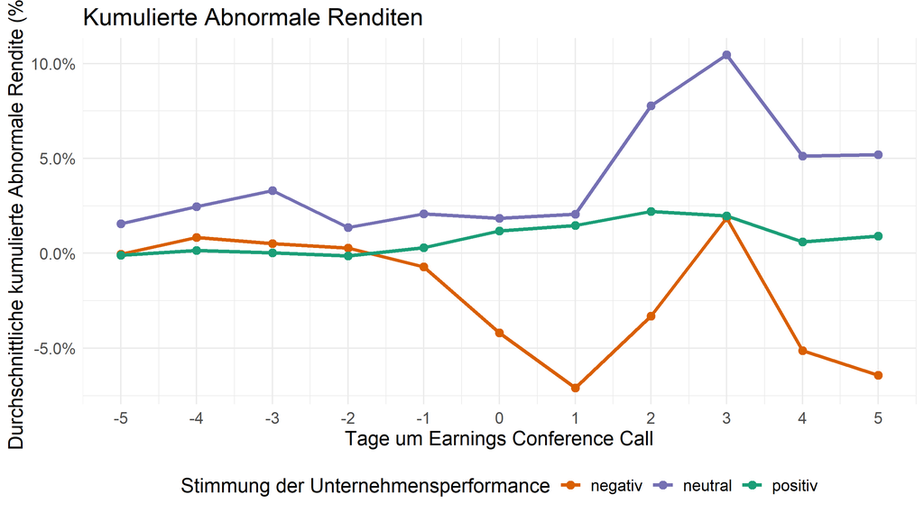

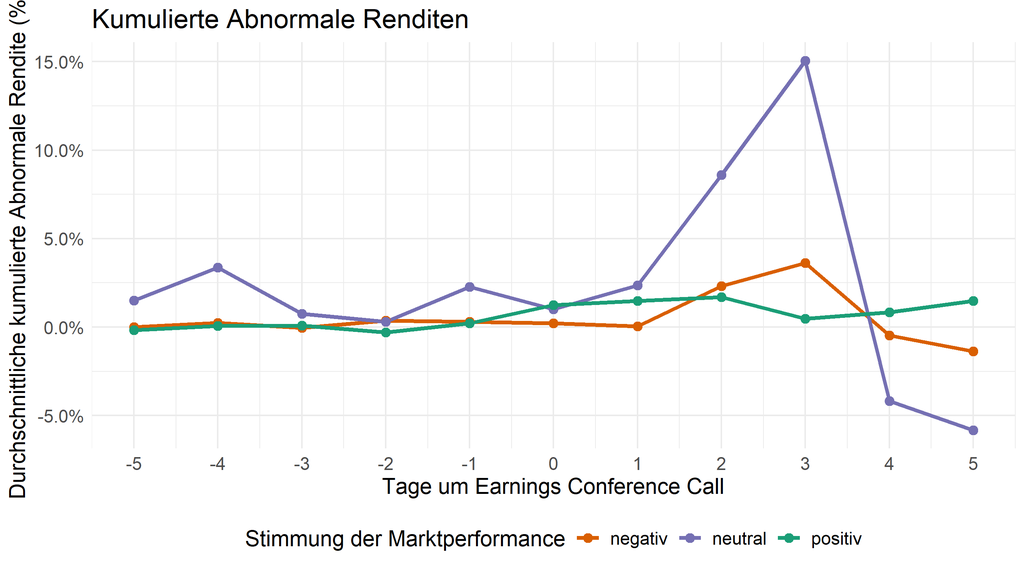

**Beschreibung und Interpretation:**

Die beiden Liniendiagramme visualisieren die durchschnittlichen kumulierten abnormalen Renditen (ar_505) im Zeitraum von fünf Tagen vor bis fünf Tagen nach den Earnings Conference Calls. Die Darstellungen sind jeweils nach der Stimmung der Calls in den Kategorien „positiv“, „neutral“ und „negativ“ getrennt – für die Unternehmensperformance und das Marktumfeld.

Für eine weiterführende Analyse wäre es empfehlenswert, die statistische Signifikanz der beobachteten Effekte zu prüfen und mögliche Einflussfaktoren wie Branchenzugehörigkeit, Marktvolatilität oder simultane Ereignisse zu berücksichtigen. Auch die Rolle der Informationsqualität und der Marktteilnehmererwartungen könnte näher untersucht werden.

**Fazit:**

# Regressionen

Sie haben bisher den Einfluss der Earnings Conference Calls auf die Aktienrendite der größten europäischen Unternehmen im Technologie-Sektor visuell betrachtet. Im letzten Abschnitt dieser Projektarbeit analysieren Sie ihre Daten mittels linearer Regressionen.

15. In dieser Aufgabe sollten Sie zwei Regressionen erstellen:

Regressieren Sie die kumulierten abnormalen Renditen um das Event `car_101` auf die Dummyvariablen

- `negativ_firm` und `negativ_market` in der ersten Regression und
- `positiv_firm` und `positiv_market` in der zweiten Regression.

Diese Dummyvariablen geben die Stimmung in den Earnings-Conference Calls wieder.

Beschreibung und interpretieren Sie ihre Regressionsergebnisse und gehen Sie dabei auch auf folgende Fragen ein:

- Was ist die Vergleichsgruppe in den beiden Regressionen?
- Was sind die Voraussetzungen für eine kausale Interpretation der Koeffizienten. Sind diese ihrer Meinung nach gegeben?

|  | Regression 1: Negative Stimmungen | Regression 2: Positive Stimmungen |
| --- | --- | --- |
| (Intercept) | 0.0171*** | -0.0464*** |
|  | (0.0020) | (0.0076) |
| negativ_firm | -0.0587*** |  |
|  | (0.0085) |  |
| negativ_market | -0.0099** |  |
|  | (0.0038) |  |
| positiv_firm |  | 0.0537*** |
|  |  | (0.0081) |
| positiv_market |  | 0.0099** |
|  |  | (0.0038) |
| Num.Obs. | 2907 | 2907 |
| R2 | 0.023 | 0.022 |
| R2 Adj. | 0.023 | 0.021 |
| AIC | -5677.1 | -5673.5 |
| BIC | -5653.2 | -5649.6 |
| Log.Lik. | 2842.566 | 2840.747 |
| F | 34.645 | 32.786 |
| RMSE | 0.09 | 0.09 |

+ p < 0.1, * p < 0.05, ** p < 0.01, *** p < 0.001

**Beschreibung der Regressionsanalysen:**

Für diese Aufgabe wurden zwei lineare Regressionen erstellt, um den Einfluss von Stimmungen aus Earnings Conference Calls auf die kumulierten abnormalen Renditen im Ereignisfenster von Tag -1 bis Tag +1 (car_101) zu analysieren.

Regression 1: Diese Regression untersucht, wie sich die car_101 durch negative Stimmungen verändert. Die unabhängigen Variablen sind negativ_firm (eine Dummy-Variable für eine negative Einschätzung der Unternehmensperformance) und negativ_market (eine Dummy-Variable für eine negative Einschätzung des Marktumfelds).

Regression 2: Diese Regression analysiert den Einfluss positiver Stimmungen auf die car_101. Die unabhängigen Variablen sind positiv_firm (eine Dummy-Variable für eine positive Einschätzung der Unternehmensperformance) und positiv_market (eine Dummy-Variable für eine positive Einschätzung des Marktumfelds).

**Interpretation der Regressionsergebnisse:**

**Regression 1: Negative Stimmungen**

- Intercept (0.0171, p < 0.001): Basis-`cmar_101` von 1.71% ohne spezifische negative Stimmungen.
- `negativ_firm` (-0.0587, p < 0.001):
  - Hoch signifikant: Negative firmenspezifische Stimmung reduziert `cmar_101` um 5.87 Prozentpunkte.
  - Bestätigt, dass negative Unternehmensnachrichten zu deutlichen negativen Kursreaktionen führen.
- `negativ_market` (-0.0099, p < 0.01):
  - Signifikant: Negative marktweite Stimmung reduziert `cmar_101` um 0.99 Prozentpunkte.
  - Deutet auf einen geringeren, aber messbaren Effekt negativer Marktaussichten hin.
- R^2 = 0.023: Nur 2.3% der `cmar_101`-Varianz werden durch diese Stimmungsindikatoren erklärt.

**Regression 2: Positive Stimmungen**

- Intercept (-0.0464, p < 0.001): Basis-`cmar_101` von -4.64% ohne spezifische positive Stimmungen.
- `positiv_firm` (0.0537, p < 0.001):
  - Hoch signifikant: Positive firmenspezifische Stimmung erhöht `cmar_101` um 5.37 Prozentpunkte.
  - Bestätigt, dass positive Unternehmensnachrichten von Investoren positiv aufgenommen werden.
- `positiv_market` (0.0099, p < 0.01):
  - Signifikant: Positive marktweite Stimmung erhöht `cmar_101` um 0.99 Prozentpunkte.
  - Ähnlicher Effekt wie bei negativer Marktstimmung, deutet auf eine symmetrische Reaktion hin.
- R^2 = 0.022: Nur 2.2% der `cmar_101`-Varianz werden durch diese Stimmungsindikatoren erklärt.

**Gesamteinschätzung**

Die Regressionsergebnisse zeigen konsistent, dass sowohl negative als auch positive Stimmungen, die in Earnings Conference Calls ausgedrückt werden, einen statistisch signifikanten Einfluss auf die kumulierten abnormalen Renditen haben. Negative Stimmungen sind mit sinkenden Renditen assoziiert, während positive Stimmungen zu steigenden Renditen führen. Firmen-spezifische Stimmungen haben dabei einen deutlich stärkeren Einfluss als marktweite Stimmungen. Die geringen R-squared-Werte in beiden Modellen weisen jedoch darauf hin, dass die betrachteten Stimmungs-Dummyvariablen nur einen kleinen Teil der Variation in den kumulierten abnormalen Renditen erklären, was bedeutet, dass andere, nicht im Modell enthaltene Faktoren einen wesentlich größeren Einfluss auf die Aktienrenditen ausüben.

**Was ist die Vergleichsgruppe in den beiden Regressionen?**

Die Vergleichsgruppe in diesen Regressionen wird durch die Kodierung der Dummy-Variablen bestimmt. Jede Dummy-Variable nimmt den Wert 1 an, wenn die entsprechende Stimmung zutrifft, und den Wert 0, wenn sie nicht zutrifft. Die Vergleichsgruppe sind folglich jene Earnings Calls, bei denen die jeweilige Stimmungs-Dummy-Variable, die in der Regression als unabhängige Variable verwendet wird, den Wert 0 aufweist.

In Regression 1 (negative Stimmungen):  
Die Vergleichsgruppe umfasst Unternehmen, bei deren Earnings Conference Calls weder eine negative firmen-spezifische Stimmung (negativ_firm = 0) noch eine negative marktweite Stimmung (negativ_market = 0) festgestellt wurde. Der Intercept der ersten Regression (0.0171) repräsentiert die durchschnittliche abnormale Rendite dieser Gruppe.

In Regression 2 (positive Stimmungen):  
Die Vergleichsgruppe umfasst Unternehmen, bei deren Earnings Conference Calls weder eine positive firmen-spezifische Stimmung (positiv_firm = 0) noch eine positive marktweite Stimmung (positiv_market = 0) festgestellt wurde. Der Intercept der zweiten Regression (−0.0464) repräsentiert die durchschnittliche abnormale Rendite dieser Gruppe.

**Unter welchen Voraussetzungen können die Koeffizienten kausal interpretiert werden? Sind diese Annahmen gegeben?**

Für eine kausale Interpretation der Regressionskoeffizienten, also die Schlussfolgerung, dass die Stimmungen in den Earnings Conference Calls die abnormalen Renditen *verursachen*, müssen mehrere strikte Annahmen erfüllt sein:

**Zeitliche Abfolge (Temporal Precedence)**

- **Definition**: Die Ursache (im Earnings Call geäußerte Stimmung) muss der Wirkung (kumulierte anormale Renditen) zeitlich vorausgehen.
- **Einschätzung**: Diese Annahme ist in diesem Kontext wahrscheinlich gegeben. Der Earnings Conference Call ist ein klar definierter, punktueller Event. Sein Inhalt wird vor der Reaktion der Aktienkurse im relevanten Ereignisfenster bekannt, was eine zeitliche Vorordnung der Ursache vor der Wirkung gewährleistet.

**Kovariation**

- **Definition**: Es muss ein statistischer Zusammenhang zwischen der potenziellen Ursache und der Wirkung bestehen.
- **Einschätzung**: Diese Annahme ist gegeben. Die Regressionsergebnisse zeigen für alle Stimmungs-Dummyvariablen (`negativ_firm`, `negativ_market`, `positiv_firm`, `positiv_market`) Koeffizienten, die auf einen statistischen Zusammenhang hindeuten.

**Ausschluss von Drittvariablen/Störfaktoren (Non-Spuriousness/Confounding)**

- **Definition**: Der beobachtete Zusammenhang darf nicht durch unbeobachtete Drittvariablen erklärt werden, die sowohl die angenommene Ursache (Stimmung) als auch die Wirkung (abnormale Renditen) beeinflussen. Es muss sichergestellt werden, dass die Stimmungsindikatoren die kausale Variable sind und nicht lediglich als Proxy für andere, eigentlich treibende Informationen dienen.
- **Einschätzung**: Diese Annahme ist meiner Meinung nach **nur bedingt gegeben**.
  - Stimmungen in Earnings Calls sind oft direkte Reaktionen auf die kommunizierten fundamentalen Informationen des Unternehmens (z.B. Gewinnprognosen, Umsatzzahlen, strategische Entscheidungen) oder des Marktes.
  - Es ist sehr wahrscheinlich, dass diese zugrundeliegenden fundamentalen Informationen selbst die primären Treiber der Aktienrenditen sind und gleichzeitig die Stimmungen im Call prägen.
  - Das aktuelle Modell kontrolliert diese fundamentalen Aspekte nicht explizit. Daher könnte der beobachtete Effekt der Stimmungen tatsächlich ein Spureneffekt der zugrundeliegenden Unternehmens- oder Marktinformationen sein. Dies führt zu einem potenziellen “omitted variable bias” (Verzerrung durch ausgelassene Variablen).
  - Um eine robustere kausale Aussage zu treffen, müsste das Modell um weitere Kontrollvariablen (z.B. tatsächliche Gewinnüberraschungen, Marktvolatilität, Sektorperformance) erweitert oder ein Forschungsdesign gewählt werden, das eine bessere Isolierung des reinen Stimmungseffekts ermöglicht (z.B. durch instrumentelle Variablen oder eine detailliertere Inhaltsanalyse, die zwischen objektiven Informationen und subjektiver Stimmungsfärbung trennt).
  - Solange diese umfassende Kontrolle nicht erfolgt ist, sollten die Koeffizienten eher als Indikatoren für eine starke Korrelation oder Assoziation interpretiert werden, nicht zwingend als direkter kausaler Beweis.
16. In ihrer deskriptiven Analyse haben Sie bereits gesehen, dass die Unternehmen, die Sie in diesem Projekt betrachten, alle unterschiedlich groß sind. Weiterhin haben Sie gesehen, dass es ein unterschiedliches Stimmungsbild in den Calls über die einzelnen Jahre hinweg gibt. Dafür möchten Sie in ihren Regressionen nun kontrollieren.
    1. Regressieren Sie die `car_101` auf die Variablen *negativ_firm* und *negativ_market* und kontrollieren Sie auf die Größe des jeweiligen Unternehmens, indem Sie die Variable *Total_Assets* in ihre Regression aufnehmen
    2. Fügen Sie in einer zweiten Analyse zusätzlich zu den Variablen aus der 1. Regression auch noch Dummyvariablen für die Jahre in dem das Event stattgefunden hat ihrer Regression hinzu.
    3. Führen Sie die Regressionen aus 1. und 2. auch für die Variablen *positiv_firm* und *positiv_market* anstatt *negativ_firm* und *negativ_market* durch, sodass Sie am Ende 4 Regressionen haben

Beschreiben und interpretieren Sie ihre Ergebnisse im Hinblick auf die Größe der Koeffizienten und deren Signifikanz. Gehen Sie insbesondere auf folgende Fragen ein:

- Warum sollte ihre Regression nicht fünf Dummyvariablen, je eine für jedes Jahr, sondern nur vier beinhalten?
- Verändert sich durch die Dummyvariablen der Koeffizient von *negativ_firm* und *negativ_market* bzw. *positiv_firm* und *positiv_market*?
- Hätten Sie eine Veränderung des Koeffizienten von *negativ_firm*, *negativ_market*, *positiv_firm* oder *positiv_market* erwartet? Begründen Sie ihre Antwort mit ihren deskriptiven Analysen.

|  | Negativ-Stimmungen + RI | Negativ-Stimmungen + RI + Jahr | Positiv-Stimmungen + RI | Positiv-Stimmungen + RI + Jahr |
| --- | --- | --- | --- | --- |
| (Intercept) | 0.0496*** | 0.0509*** | -0.0121 | -0.0103 |
|  | (0.0069) | (0.0076) | (0.0102) | (0.0105) |
| negativ_firm | -0.0558*** | -0.0504*** |  |  |
|  | (0.0085) | (0.0085) |  |  |
| negativ_market | -0.0112** | -0.0161*** |  |  |
|  | (0.0038) | (0.0039) |  |  |
| log(RI) | -0.0046*** | -0.0047*** | -0.0047*** | -0.0048*** |
|  | (0.0009) | (0.0009) | (0.0009) | (0.0009) |
| Y2021 |  | -0.0074 |  | -0.0072 |
|  |  | (0.0056) |  | (0.0056) |
| Y2022 |  | 0.0052 |  | 0.0061 |
|  |  | (0.0055) |  | (0.0055) |
| Y2023 |  | 0.0085 |  | 0.0086 |
|  |  | (0.0055) |  | (0.0055) |
| Y2024 |  | -0.0150** |  | -0.0143* |
|  |  | (0.0056) |  | (0.0056) |
| Y2025 |  | 0.0239*** |  | 0.0252*** |
|  |  | (0.0071) |  | (0.0071) |
| positiv_firm |  |  | 0.0516*** | 0.0454*** |
|  |  |  | (0.0081) | (0.0082) |
| positiv_market |  |  | 0.0112** | 0.0166*** |
|  |  |  | (0.0038) | (0.0039) |
| Num.Obs. | 2907 | 2907 | 2907 | 2907 |
| R2 | 0.031 | 0.045 | 0.031 | 0.044 |
| R2 Adj. | 0.030 | 0.042 | 0.030 | 0.041 |
| AIC | -5699.3 | -5729.1 | -5697.0 | -5727.2 |
| BIC | -5669.4 | -5669.4 | -5667.1 | -5667.4 |
| Log.Lik. | 2854.652 | 2874.559 | 2853.477 | 2873.597 |
| F | 31.361 | 16.898 | 30.554 | 16.647 |
| RMSE | 0.09 | 0.09 | 0.09 | 0.09 |

+ p < 0.1, * p < 0.05, ** p < 0.01, *** p < 0.001

**Beschreibung der Regressionsanalysen:**

Für diese Aufgabe wurden vier lineare Regressionen erstellt, um den Einfluss von Stimmungen aus Earnings Conference Calls auf die kumulierten abnormalen Renditen (car_101) zu analysieren, wobei zusätzlich für Unternehmensgröße und Jahreseffekte kontrolliert wird. Die abhängige Variable in allen vier Regressionen ist car_101.

Regression 1 (“Negativ-Stimmungen + RI”): Regressiert car_101 auf negativ_firm und negativ_market, kontrolliert für die Unternehmensgröße mittels der Logarithmierung der Bilanzsumme (log(RI), wobei RI für Total_Assets steht).

Regression 2 (“Negativ-Stimmungen + RI + Jahr”): Erweitert Regression 1 um Dummyvariablen für die Jahre des Events (Y2021, Y2022, Y2023, Y2024, Y2025).

Regression 3 (“Positiv-Stimmungen + RI”): Regressiert car_101 auf positiv_firm und positiv_market, kontrolliert für die Unternehmensgröße mittels log(RI).

Regression 4 (“Positiv-Stimmungen + RI + Jahr”): Erweitert Regression 3 um Dummyvariablen für die Jahre des Events (Y2021, Y2022, Y2023, Y2024, Y2025).

**Interpretation der Regressionsergebnisse:**

Allgemeine Beobachtungen über alle Regressionen:  
Die Ergebnisse zeigen, dass die Kontrolle für Unternehmensgröße (log(RI)) und Jahreseffekte die R-squared-Werte der Modelle leicht erhöht, was auf eine verbesserte Erklärungskraft hindeutet. Der log(RI)-Koeffizient ist in allen vier Regressionen negativ (ca. -0.0046 bis -0.0048). Dies bedeutet, dass größere Unternehmen (gemessen an der Bilanzsumme) tendenziell geringere kumulierte abnormale Renditen aufweisen, was ein bekanntes Phänomen in der Finanzmarktforschung ist (Size-Effect oder größere Unternehmen reagieren weniger volatil auf spezifische Events). Der RMSE bleibt in allen Modellen konstant bei 0.09.

**Spezifische Interpretation der einzelnen Regressionen**

**Regression 1 (Negativ-Stimmungen + RI)**

- Intercept: 0.0496. Basis-CAR für Unternehmen mit Bilanzsumme 1 ohne negative Stimmungen.
- `negativ_firm`: -0.0558. Starker negativer Effekt; CARs sind um ca. 5.58 Prozentpunkte geringer.
- `negativ_market`: -0.0112. Negativer Effekt; CARs sinken um ca. 1.12 Prozentpunkte.
- `log(RI)`: -0.0046. Unternehmensgröße beeinflusst CARs negativ.
- R2 Adj.: 0.030. Erklärungskraft verbessert sich durch Einbeziehung der Unternehmensgröße.

**Regression 2 (Negativ-Stimmungen + RI + Jahr)**

- Intercept: 0.0509. Basiswert ähnlich.
- `negativ_firm`: -0.0504. Negativer Effekt bleibt, leicht reduziert auf 5.04 Prozentpunkte.
- `negativ_market`: -0.0161. Negativer Effekt bleibt, leicht erhöht auf 1.61 Prozentpunkte.
- `log(RI)`: -0.0047. Negativer Einfluss der Unternehmensgröße bleibt.
- Jahres-Dummies:
  - Y2021: -0.0074.
  - Y2022: 0.0052.
  - Y2023: 0.0085.
  - Y2024: -0.0150. CARs um 1.50 Prozentpunkte geringer als Basisjahr.
  - Y2025: 0.0239. CARs um 2.39 Prozentpunkte höher als Basisjahr.
- R2 Adj.: 0.042. Weitere Verbesserung der Erklärungskraft durch Jahreseffekte.

**Regression 3 (Positiv-Stimmungen + RI)**

- Intercept: -0.0121.
- `positiv_firm`: 0.0516. Positivem Effekt; CARs steigen um ca. 5.16 Prozentpunkte.
- `positiv_market`: 0.0112. Positivem Effekt; CARs steigen um ca. 1.12 Prozentpunkte.
- `log(RI)`: -0.0047. Negativer Einfluss der Unternehmensgröße bleibt.
- R2 Adj.: 0.030. Erklärungskraft verbessert sich durch Einbeziehung der Unternehmensgröße.

**Regression 4 (Positiv-Stimmungen + RI + Jahr)**

- Intercept: -0.0103.
- `positiv_firm`: 0.0454. Positiver Effekt bleibt, leicht reduziert auf 4.54 Prozentpunkte.
- `positiv_market`: 0.0166. Positiver Effekt bleibt, leicht erhöht auf 1.66 Prozentpunkte.
- `log(RI)`: -0.0048. Negativer Einfluss der Unternehmensgröße bleibt.
- Jahres-Dummies:
  - Y2021: -0.0072.
  - Y2022: 0.0061.
  - Y2023: 0.0086.
  - Y2024: -0.0143. Negative CARs im Vergleich zum Basisjahr.
  - Y2025: 0.0252. Positive CARs im Vergleich zum Basisjahr.
- R2 Adj.: 0.041. Weitere Verbesserung der Erklärungskraft durch Jahreseffekte.

**Warum sollte ihre Regression nicht fünf Dummyvariablen, je eine für jedes Jahr, sondern nur vier beinhalten?**

In einer Regression mit kategorialen Variablen, wie den Jahres-Dummies, wird immer eine Kategorie als Referenzkategorie (Basislinie) ausgelassen, um das Problem der Multikollinearität (Dummy Variable Trap) zu vermeiden. Wenn alle fünf Jahre (z.B. Y2021 bis Y2025, falls diese die einzigen Jahre im Datensatz sind) als separate Dummyvariablen in das Modell aufgenommen würden, wäre die Summe dieser Dummyvariablen eine Konstante (nämlich 1 für jede Beobachtung). Diese konstante Summe würde perfekt mit dem Intercept des Regressionsmodells korrelieren, was zu einer perfekten Multikollinearität führt und die Schätzung der Koeffizienten unmöglich macht. Indem ein Jahr ausgelassen wird (z.B. ein Jahr vor 2021 oder eines der Jahre 2021-2025 als Basis), werden die Koeffizienten der verbleibenden Jahres-Dummies als Differenz zum Referenzjahr interpretiert.

**Verändert sich durch die Dummyvariablen der Koeffizient von negativ_firm und negativ_market bzw. positiv_firm und positiv_market?**

**Hätten Sie eine Veränderung des Koeffizienten von negativ_firm, negativ_market, positiv_firm oder positiv_market erwartet? Begründen Sie ihre Antwort mit ihren deskriptiven Analysen.**

Ja, eine Veränderung der Koeffizienten wäre erwartet worden. Die Begründung liegt in der Aussage der Aufgabenstellung selbst und Ihrer deskriptiven Analyse: “Weiterhin haben Sie gesehen, dass es ein unterschiedliches Stimmungsbild in den Calls über die einzelnen Jahre hinweg gibt.” Wenn die Stimmung in den Calls (Ihre unabhängigen Variablen) systematisch über die Jahre variiert und gleichzeitig die kumulierten abnormalen Renditen auch über die Jahre hinweg variieren, dann besteht eine Korrelation zwischen den Stimmungen und den Jahres-Dummies. Das Hinzufügen der Jahres-Dummies ermöglicht es dem Modell, diesen “geteilten” Effekt zu isolieren. Die Anpassung der Koeffizienten in Ihrem Ergebnis bestätigt diese Erwartung, da sich die Werte für die Stimmungs-Dummyvariablen leicht ändern, nachdem die Jahreseffekte kontrolliert wurden.

17. Zum Abschluss sollten Sie dazu Stellung beziehen, in wie weit die Erkenntnisse aus diesem Projekt für eine Handelsstrategie genutzt werden könnten. Konkret sollten Sie erläutern ob es sinnvoll ist eine Unternehmensaktie bei einem negativem Sentiment im Earnings Conference Call automatisiert zu verkaufen.

Beziehen Sie sich in ihrer Argumentation insbesondere auf:

- Zeitliche Aspekte (Wann reagiert der Markt vs. wann liegt das Sentiment vor?)
- Methodische Limitationen Ihrer Event Study
- Unsicherheiten bei der LLM-Sentiment-Analyse

Begründen Sie jeden Kritikpunkt konkret mit Bezug auf Ihre Projektarbeit und schließen Sie mit einer realistischen Einschätzung ab: Wofür könnten Ihre Ergebnisse trotz dieser Limitationen in der Praxis dennoch wertvoll sein?

Die in unserem Projekt gewonnenen Erkenntnisse bieten eine Grundlage für die Entwicklung von Handelsstrategien, indem sie aufzeigen, dass die Stimmungen in Earnings Conference Calls signifikante Auswirkungen auf abnormale Renditen haben. Die empirischen Ergebnisse belegen, dass negative Stimmungen mit einem Rückgang der kumulierten abnormalen Renditen assoziiert sind, während positive Stimmungen einen Anstieg bewirken. Dennoch erfordert die konkrete Frage, ob es sinnvoll ist, eine Unternehmensaktie bei einem negativen Sentiment im Earnings Conference Call automatisiert zu verkaufen, eine kritische Betrachtung verschiedener Aspekte, darunter zeitliche Gegebenheiten, methodische Limitationen unserer Event Study und Unsicherheiten, die sich aus der LLM-basierten Sentiment-Analyse ergeben.

**Zeitliche Aspekte** spielen eine entscheidende Rolle. Unsere Event Study (Aufgabe 14) zeigt, dass die signifikantesten Marktreaktionen unmittelbar am oder kurz nach dem Eventtag (Tag 0) auftreten. Negative Stimmungen führen bereits vor Tag 0 zu einem leichten Renditerückgang, der sich nach dem Call verstärkt, während positive Stimmungen direkt nach Tag 0 zu einem Anstieg führen. Dies deutet auf eine rasche Informationsverarbeitung durch den Markt hin. Für eine automatisierte Handelsstrategie ist es unerlässlich, das Sentiment des Earnings Calls in nahezu Echtzeit zu erfassen und zu verarbeiten. Da die Sentiment-Analyse der Transkripte jedoch eine gewisse Verzögerung aufweist – die Transkripte müssen erst erstellt und das Sentiment extrahiert werden, was Stunden bis Tage dauern kann –, könnte der Großteil der relevanten Marktreaktion bereits erfolgt sein, bevor die Strategie aktiv werden kann. Ein automatisierter Verkauf auf Basis eines verspätet vorliegenden negativen Sentiments würde möglicherweise die größten Kursrückgänge verpassen oder sogar erfolgen, wenn der Markt bereits eine Gegenbewegung einleitet.

Hinzu kommen **methodische Limitationen unserer Event Study**. Obwohl sie ein etabliertes Instrument zur Untersuchung durchschnittlicher Marktreaktionen darstellt, hat sie ihre Grenzen. Unsere Grafiken in Aufgabe 14 visualisieren durchschnittliche kumulierte abnormale Renditen; dies bedeutet nicht, dass jedes einzelne Event dieselbe Reaktion hervorruft. Eine Strategie, die sich ausschließlich auf den Durchschnitt stützt, birgt somit Risiken bei individuellen Aktienbewegungen. Des Weiteren besteht das sogenannte Joint-Test-Problem: Es ist schwierig, die kausale Wirkung des Sentiments von anderen, oft gleichzeitig veröffentlichten fundamentalen Informationen (z.B. Gewinnzahlen oder Zukunftsprognosen) zu trennen. Obwohl unsere Regressionen (Aufgabe 15 und 16) einen statistisch signifikanten Zusammenhang zwischen Sentiment und abnormalen Renditen aufzeigen, erklären die sehr niedrigen R-squared-Werte (2-4%) nur einen geringen Teil der Varianz in den abnormalen Renditen. Dies impliziert, dass der überwiegende Teil der Kursbewegungen durch andere, nicht im Modell erfasste Faktoren bestimmt wird. Das Fehlen weiterer Kontrollvariablen (z.B. Branchenzugehörigkeit, Marktvolatilität, Managementqualität) schränkt zudem die kausale Interpretierbarkeit des reinen Sentiment-Effekts ein. Eine Handelsstrategie, die nur auf Sentiment basiert, würde diese entscheidenden Kontextvariablen ignorieren.

Schließlich sind **Unsicherheiten bei der LLM-Sentiment-Analyse** zu berücksichtigen. Obwohl große Sprachmodelle wie Google Gemini 2.5 Flash leistungsfähig sind, ist die Sprache in Finanzkommunikation oft nuanciert, geschäftsspezifisch und kann euphemistisch sein. Ein “neutrales” Sentiment könnte beispielsweise bewusst vage gehalten sein, um negative Nachrichten zu kaschieren. Das LLM könnte solche subtilen Bedeutungen, Sarkasmus oder Ironie möglicherweise nicht immer vollständig oder korrekt erfassen. Die “Black-Box”-Natur dieser Modelle erschwert zudem die Nachvollziehbarkeit ihrer Entscheidungen, was die Identifikation und Korrektur von Fehlinterpretationen erschwert.

Zusammenfassend lässt sich festhalten, dass ein automatisierter Verkauf einer Unternehmensaktie, der allein auf einem negativen Sentiment aus einem Earnings Conference Call basiert, nicht als sinnvoll erachtet werden kann und erhebliche Risiken birgt. Der geringe Erklärungsanteil des Sentiments an den Aktienrenditen würde zu einer hohen Rate an Fehlsignalen und potenziell erheblichen Verlusten führen, da zahlreiche stärkere Einflussfaktoren unberücksichtigt blieben.

Trotz dieser Limitationen sind **unsere Forschungsergebnisse in der Praxis dennoch wertvoll**. Die Analyse des Sentiments in Earnings Conference Calls durch LLMs kann als ergänzende Informationsquelle in umfassenderen Anlageentscheidungen oder komplexeren Handelsstrategien dienen. Das Sentiment könnte beispielsweise als Filter fungieren, um Unternehmen mit einem extrem negativen oder positiven Stimmungsbild für eine vertiefte manuelle Analyse zu selektieren. Darüber hinaus können die LLM-basierten Sentiment-Scores als quantifizierbare Kennzahlen für qualitative Aspekte der Unternehmenskommunikation dienen, was Anlegern eine strukturiertere Einbeziehung von “weichen Faktoren” wie dem Managementton oder Zukunftsaussichten in die fundamentale Analyse ermöglicht. Die erarbeiteten Sentiment-Daten und die Event-Study-Struktur bieten zudem eine exzellente Basis für weiterführende Forschung und die Entwicklung von noch komplexeren quantitativen Modellen, die Sentiment mit anderen relevanten Finanzdaten kombinieren.

# Zusatzaufgabe

In Aufgabe 6 berechnen Sie die *abnormalen Renditen* der einzelnen von ihnen betrachteten Unternehmen. Nun könnte es allerdings sein, dass es nicht ausreicht den Marktindex einfach von der Aktienrendite abzuziehen um für die erwartete Performance der Aktie zu kontrollieren. Potentiell wäre es besser für die durchschnittliche Performance der Aktie zu kontrollieren in der keine Events stattfinden.

Sie können eine solche durchschnittliche Performance schätzen. Dazu sollten Sie eine Schätzperiode *vor* dem Event definieren. Diese Periode sollen Sie auf 120 bis 10 Handelstage vor dem Event festlegen. Die durchschnittliche Rendite der Einzelaktie sollten Sie in dieser Periode auf die Marktrendite regressieren. Dieses Modell wird `Risk-adjusted returns model` in Huntington-Klein (2021) genannt:

$$\begin{equation}
\hat{Rendite}_{i,t} = \alpha + \beta Rendite_{m,t}
\end{equation}$$

Anschließend nutzen Sie die vorhergesagten Werte und ziehen diese in der Eventphase von der Rendite der Einzelaktie ab.

18. Erstellen Sie die kumulierten abnormalen Renditen im Zeitraum -5 bis +5 mit Hilfe ihres Risk-adjusted returns model neu (und nennen diese `mar_505`). Erstellen Sie die kumulierten abnormalen Renditen im Zeitraum -1 bis +1 um das Event mit Hilfe ihres Risk-adjusted returns model neu (und nennen die Variable `cmar_101`) und vergleichen die Werte in einer geeigneten Grafik mit den Ergebnissen aus dem market-adjusted returns model (`car_101`).
- Gibt es hier große Unterschiede?
- Warum gibt es diese Unterschiede, oder warum sehen Sie nur geringe Unterschiede?

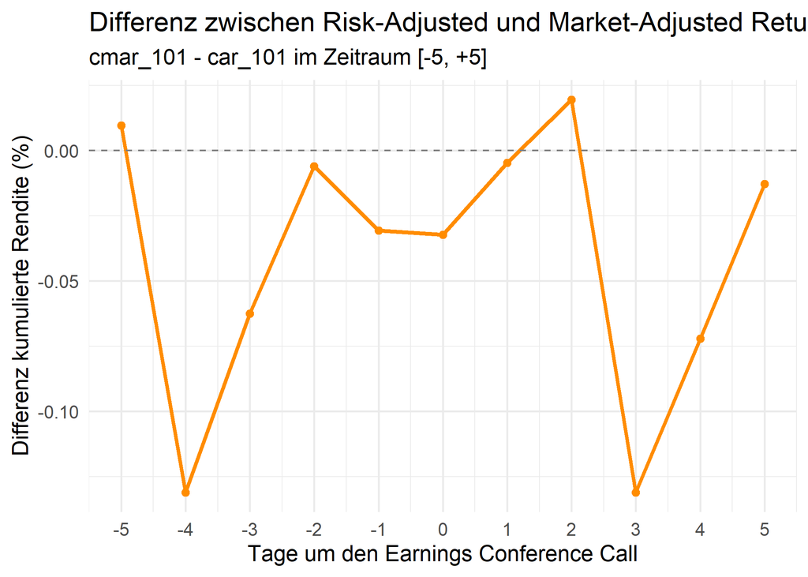

Im Rahmen unserer Zusatzaufgabe haben wir das Konzept des Risk-adjusted returns model (auch bekannt als Market Model) angewendet, um eine präzisere Schätzung der erwarteten Aktienrenditen vorzunehmen. Dieses Modell geht über die einfache Marktanpassung hinaus, indem es die individuelle Beziehung jeder Aktie zum Markt berücksichtigt. Es wird durch die Gleichung
$$\begin{equation}
\hat{Rendite}_{i,t} = \alpha + \beta Rendite_{m,t}
\end{equation}$$
beschrieben, wobei $\hat{Rendite}_{i,t}$ die erwartete Rendite der Aktie $i$ zum Zeitpunkt $t$ ist, $\alpha$ einen aktienspezifischen konstanten Faktor (der eine systematische Über- oder Unterperformance abbilden kann) und $\beta$ die Sensitivität der Aktie gegenüber Marktbewegungen darstellt. Um diese Parameter zu schätzen, wurde für jeden einzelnen Event (Earnings Conference Call) eine eigene Regression durchgeführt. Dabei haben wir die täglichen Renditen der Einzelaktie auf die täglichen Marktrenditen in einer Schätzperiode von 120 bis 10 Handelstagen vor dem jeweiligen Event regressiert. Mit den so gewonnenen, aktienspezifischen $\hat{\alpha}$- und $\hat{\beta}$-Werten konnten wir anschließend die erwarteten Renditen für jeden Tag im Eventfenster von -5 bis +5 Handelstagen prognostizieren. Die neuen, bereinigten abnormalen Renditen ($AR_{i,t}$) ergaben sich dann, indem diese erwarteten Renditen von den tatsächlichen Aktienrenditen abgezogen wurden, woraus sich die kumulierten Werte `mar_505` und `cmar_101` ergeben.

19. Erstellen Sie die Grafik von Aufgabe 12 neu.

Beschreiben und interpretieren Sie ihre Grafik. Gehen Sie auch auf folgende Fragen ein:

- Könnte es zu Problemen führen, wenn in der Schätzperiode vor dem Event ein weiterer Earnings-Conference Call enthalten ist?
  - Warum könnte dies ein Problem sein, oder warum nicht?

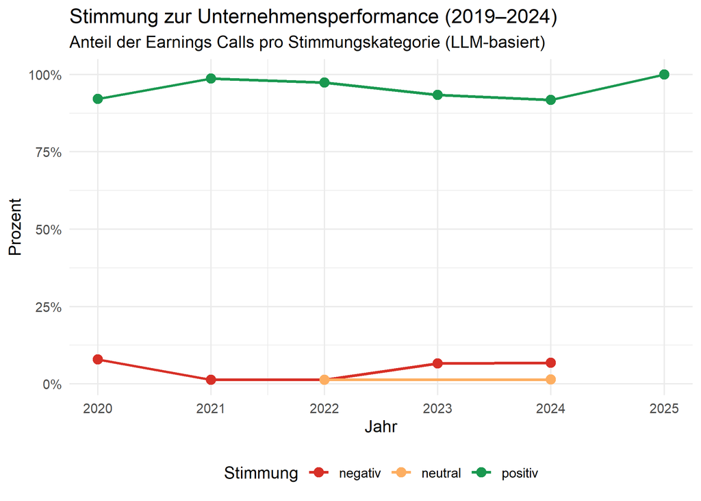

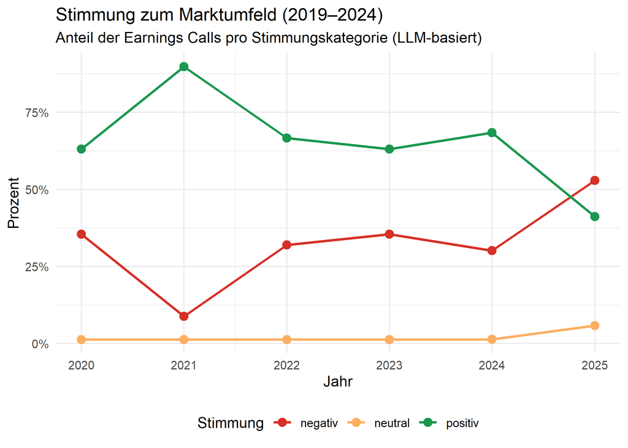

**Beschreibung der Grafiken**

Die beiden vorliegenden Liniendiagramme visualisieren die Entwicklung der Stimmungen in Earnings Calls über die Jahre 2020 bis 2025, basierend auf Large Language Model (LLM)-Analysen. Sie zeigen den jährlichen Anteil der Anrufe, die als negativ, neutral oder positiv kategorisiert wurden.

**Grafik 1: Stimmung zur Unternehmensperformance (2020–2025)**

Diese Grafik stellt den Anteil der Earnings Calls dar, bei denen die Stimmung bezüglich der Unternehmensperformance als negativ, neutral oder positiv eingestuft wurde.

- Die positive Stimmung (grüne Linie) dominierte den Großteil des Zeitraums und lag konstant über 90% in den Jahren 2020 bis 2022. Sie fiel leicht auf etwa 95% in den Jahren 2023 und 2024, bevor sie 2025 wieder auf nahezu 100% anstieg.
- Die negative Stimmung (rote Linie) verzeichnete im Jahr 2020 einen geringen Anteil von etwa 10%, sank dann in den Jahren 2021 und 2022 auf nahezu 0% und zeigte in den Jahren 2023 und 2024 einen leichten Anstieg auf etwa 5%. Im Jahr 2025 fällt sie wieder auf nahezu 0%.
- Die neutrale Stimmung (orange Linie) ist über den gesamten Zeitraum hinweg sehr gering, nahe der 0%-Achse, mit einem kleinen Anstieg in den Jahren 2022-2024.

**Grafik 2: Stimmung zum Marktumfeld (2020–2025)**

Diese Grafik zeigt den Anteil der Earnings Calls, bei denen die Stimmung bezüglich des Marktumfelds als negativ, neutral oder positiv eingestuft wurde.

**Interpretation der Grafiken**

Die beiden Liniendiagramme bieten wichtige Einblicke in die zeitliche Entwicklung der kommunizierten Stimmungen in Earnings Calls:

- Dominanz positiver Unternehmensperformance-Stimmung: In Bezug auf die Unternehmensperformance wird fast ausschließlich positiv kommuniziert. Dies deutet darauf hin, dass Unternehmen in ihren Earnings Calls dazu neigen, die eigene Performance überwiegend optimistisch darzustellen. Die leichte Zunahme negativer und neutraler Töne in den Jahren 2023-2024 könnte auf externen Druck oder eine realistischere Einschätzung der Lage in einem möglicherweise herausfordernderen Umfeld hindeuten, bevor der Optimismus 2025 zurückkehrt. Die geringe Präsenz neutraler Stimmungen unterstreicht, dass das Management in Bezug auf die eigene Firma selten eine “neutrale” Haltung einnimmt.
- Dynamischere Marktstimmung: Im Gegensatz zur stabil positiven Selbstwahrnehmung der Unternehmen zeigt die Stimmung zum Marktumfeld eine deutlich dynamischere Entwicklung und spiegelt wahrscheinlich die tatsächlichen Schwankungen der globalen Wirtschaftslage wider. Der Rückgang der positiven Marktstimmung und der gleichzeitige Anstieg der negativen Marktstimmung ab 2021/2022 bis 2025 könnte mit makroökonomischen Herausforderungen wie Inflation, Zinsanstiegen oder geopolitischen Spannungen korrelieren, die sich auch in den Aussagen des Managements über das externe Umfeld niederschlagen. Der signifikante Anstieg der negativen Marktstimmung im Jahr 2025 ist besonders auffällig und deutet auf eine Eintrübung der allgemeinen Marktaussichten aus Sicht der Unternehmen hin.
- Divergenz der Stimmungen: Die auffällige Divergenz zwischen der überwiegend positiven Darstellung der Unternehmensperformance und der volatileren, teils pessimistischeren Einschätzung des Marktumfelds unterstreicht einen wichtigen Aspekt der Managementkommunikation: Während die eigene Leistung oft optimistisch dargestellt wird, ist die Einschätzung externer Faktoren realistischer und spiegelt sich stärker in den Daten wider. Dies könnte ein Hinweis darauf sein, dass Unternehmen dazu neigen, ihre eigenen Leistungen im besten Licht darzustellen, aber die externen Herausforderungen nicht ignorieren können, was sich in den Äußerungen zum Marktumfeld niederschlägt.

**Könnte es zu Problemen führen, wenn in der Schätzperiode vor dem Event ein weiterer Earnings-Conference Call enthalten ist?**

Ja, es könnte zu erheblichen Problemen führen, wenn in der Schätzperiode vor dem Haupt-Event (dem Earnings Conference Call, den wir gerade analysieren) ein weiterer Earnings Conference Call desselben Unternehmens enthalten ist.

**Warum könnte dies ein Problem sein, oder warum nicht?**

Dies stellt ein potenzielles Problem dar, da die Schätzperiode (120 bis 10 Handelstage vor dem Event) dazu dient, die “normale” Beziehung zwischen der Aktienrendite und der Marktrendite zu ermitteln. Diese normale Beziehung wird durch die Parameter $\alpha$ und $\beta$ im Risk-adjusted returns model repräsentiert. Wenn in dieser Schätzperiode ein weiterer signifikanter Informations-Event wie ein Earnings Conference Call stattfindet, sind die Aktienrenditen an diesen Tagen wahrscheinlich abnormal und nicht “normal”. Das bedeutet, die Annahmen über das stabile Renditegenerierungsprozess in der Schätzperiode könnten verletzt werden.

Die Aufnahme solcher abnormalen Renditen in die Regression zur Schätzung von $\alpha$ und $\beta$ würde zu verzerrten (biased) Schätzungen dieser Parameter führen. Wenn $\alpha$ und $\beta$ nicht korrekt geschätzt werden, dann sind auch die anschließend prognostizierten erwarteten Renditen für das eigentliche Eventfenster fehlerhaft. Dies wiederum würde dazu führen, dass die berechneten abnormalen Renditen für das zu untersuchende Event ebenfalls verzerrt sind und somit der tatsächliche Effekt des Events nicht korrekt abgebildet wird. Man könnte einen Teil der abnormalen Rendite des aktuellen Events fälschlicherweise der “normalen” Performance zuschreiben, oder umgekehrt.

Aus diesem Grund wird in einer sorgfältigen Event Study in der Regel darauf geachtet, die Schätzperiode von allen anderen bekannten, kursrelevanten Ereignissen zu “bereinigen”. Man würde Zeiträume um andere Earnings Conference Calls oder ähnliche große Nachrichtenereignisse aus der Schätzperiode ausschließen, um sicherzustellen, dass die geschätzten $\alpha$ und $\beta$ tatsächlich die normale Markt-Aktien-Beziehung widerspiegeln. Eine Situation, in der ein Earnings Conference Call in der Schätzperiode liegt, könnte also die Gültigkeit und die kausale Interpretierbarkeit der Ergebnisse unserer Event Study stark beeinträchtigen.

20. Lesen Sie das Kapitel [“Fixed Effects” in Huntington-Klein (2021)](https://theeffectbook.net/ch-FixedEffects.html#how-does-it-work), speziell Kapitel 16.1
21. Regressieren Sie die `cmar_101` auf die Variablen *negativ_firm* und *negativ_market* und kontrollieren Sie auf die Größe des jeweiligen Unternehmens, indem Sie die Variable *Total_Assets* in ihre Regression aufnehmen. Kontrollieren Sie weiterhin auf das Jahr in dem das Event stattgefunden hat. Fügen Sie weiterhin der Regression Firmen-Fixe Effekte hinzu.

Beschreiben und interpretieren Sie ihre Ergebnisse.

Gehen Sie zusätzlich auf die folgenden Frage ein:

- Was sind Firmen-Fixe Effekte und warum könnten diese für ihre Regression sinnvoll sein?

*Hinweis:* Mit dem [Paket `fixest`](https://cran.r-project.org/web/packages/fixest/vignettes/fixest_walkthrough.html) und der Funktion feols() können Sie einfach ihren Regressionen fixe Effekte hinzufügen

|  | Negativ-Stimmungen (mit Firm FE) | Positiv-Stimmungen (mit Firm FE) |
| --- | --- | --- |
| negativ_firm | -0.0363 |  |
|  | (0.0468) |  |
| negativ_market | -0.0154 |  |
|  | (0.0097) |  |
| log(RI) | -0.0362*** | -0.0364*** |
|  | (0.0077) | (0.0078) |
| Y2021 | 0.0055 | 0.0057 |
|  | (0.0136) | (0.0132) |
| Y2022 | 0.0162 | 0.0167 |
|  | (0.0108) | (0.0107) |
| Y2023 | 0.0197 | 0.0196 |
|  | (0.0200) | (0.0201) |
| Y2024 | -0.0041 | -0.0038 |
|  | (0.0149) | (0.0147) |
| Y2025 | 0.0305 | 0.0313 |
|  | (0.0233) | (0.0233) |
| positiv_firm |  | 0.0326 |
|  |  | (0.0422) |
| positiv_market |  | 0.0154+ |
|  |  | (0.0078) |
| Num.Obs. | 2879 | 2879 |
| R2 | 0.115 | 0.115 |
| R2 Adj. | 0.104 | 0.104 |
| R2 Within | 0.054 | 0.054 |
| R2 Within Adj. | 0.051 | 0.051 |
| AIC | -5790.6 | -5789.9 |
| BIC | -5563.9 | -5563.2 |
| RMSE | 0.09 | 0.09 |
| Std.Errors | by: ric | by: ric |
| FE: ric | X | X |

+ p < 0.1, * p < 0.05, ** p < 0.01, *** p < 0.001

**Beschreibung der Regressionsergebnisse:**

Die Koeffizienten und deren Signifikanz sind wie folgt:

Die Regression basiert auf 2879 Beobachtungen. Das Bestimmtheitsmaß R^2 beträgt 0.115, was bedeutet, dass etwa 11.5% der Varianz von `cmar_101` durch das Modell erklärt werden. Das angepasste R^2 (R^2 Adj.) liegt bei 0.104.

**Interpretation der Ergebnisse:**

Die Interpretation der Regressionsergebnisse basiert auf der Spalte “Negativ-Stimmungen (mit Firm FE)”:

- Einfluss von negativer Stimmung (Firmenspezifisch und Marktbezogen): Die Ergebnisse zeigen, dass weder die firmenspezifische negative Stimmung (`negativ_firm`) noch die marktbezogene negative Stimmung (`negativ_market`) einen statistisch signifikanten Einfluss auf den kumulativen anormalen Return (`cmar_101`) haben, wenn für Unternehmensgröße, Jahreseffekte und Firmen-Fixe Effekte kontrolliert wird. Dies bedeutet, dass unter den gegebenen Kontrollen eine Zunahme der negativen Stimmung, sei es auf Unternehmens- oder Marktebene, nicht zu einer statistisch nachweisbaren Änderung des `cmar_101` führt.
- Einfluss der Unternehmensgröße (`log(RI)`): Der negative und hoch signifikante Koeffizient von -0.0362 für `log(RI)` deutet darauf hin, dass größere Unternehmen (gemessen durch RI) tendenziell geringere kumulative anormale Renditen aufweisen. Dies könnte bedeuten, dass größere Unternehmen entweder weniger auf bestimmte Ereignisse reagieren oder dass deren `cmar_101` aus anderen, mit der Größe korrelierten Gründen niedriger ausfällt. Eine Erhöhung des Logarithmus der Unternehmensgröße um eine Einheit ist mit einem Rückgang des `cmar_101` um 0.0362 Einheiten verbunden, unter der Annahme, dass alle anderen Faktoren konstant bleiben.
- Einfluss der Jahreskontrollen: Die nicht signifikanten Koeffizienten für die Jahres-Dummy-Variablen (`Y2021` bis `Y2025`) implizieren, dass es in dem untersuchten Zeitraum (2021-2025) keine signifikanten zeitlichen Trends oder Unterschiede im `cmar_101` gab, die nicht bereits durch die anderen Variablen und die Firmen-Fixen Effekte erklärt wurden. Das heißt, das Jahr des Ereignisses selbst hatte keinen zusätzlichen signifikanten Einfluss.
- Modellerklärungskraft: Das R^2 von 0.115 weist darauf hin, dass nur ein geringer Teil der Variation im `cmar_101` durch die in diesem Modell berücksichtigten Variablen erklärt wird. Dies lässt vermuten, dass weitere Faktoren, die nicht im Modell enthalten sind, einen größeren Einfluss auf die kumulativen anomalen Renditen haben.

**Was sind Firmen-Fixe Effekte und warum könnten diese für Ihre Regression sinnvoll sein?**

**Definition von Firmen-Fixen Effekten:**

Firmen-Fixe Effekte (engl. *Firm Fixed Effects*, kurz FE) sind eine Methode in der ökonometrischen Analyse von Paneldaten, die dazu dient, unbeobachtete, zeitkonstante Heterogenität auf Firmenebene zu kontrollieren. Wenn man Daten über mehrere Zeitpunkte für dieselben Unternehmen hat, gibt es oft Merkmale, die sich zwischen den Unternehmen unterscheiden, aber über die Zeit für ein bestimmtes Unternehmen konstant bleiben. Solche Merkmale könnten zum Beispiel die Qualität des Managements, die Unternehmenskultur, das grundlegende Geschäftsmodell oder dauerhafte Wettbewerbsvorteile sein, die schwer direkt zu messen sind.

Die Kernidee der Firmen-Fixen Effekte besteht darin, diese firmenspezifischen, zeitlich invarianten Effekte aus der Analyse zu entfernen. Technisch wird dies erreicht, indem entweder für jede Firma eine separate Dummy-Variable in die Regression aufgenommen wird oder durch eine sogenannte “Within-Transformation” der Daten. Bei der Within-Transformation wird für jede Variable der firmenspezifische Mittelwert über die Zeit von den einzelnen Beobachtungen abgezogen. Dadurch werden alle firmenspezifischen Komponenten, die sich über die Zeit nicht ändern, eliminiert.

**Sinnhaftigkeit von Firmen-Fixen Effekten für die Regression:**

Die Aufnahme von Firmen-Fixen Effekten ist für die vorliegende Regression aus mehreren Gründen äußerst sinnvoll:

1. Kontrolle unbeobachteter firmenspezifischer Heterogenität: Unternehmen sind sehr unterschiedlich. Diese Unterschiede (z.B. Branchenzugehörigkeit, Größe, Reputation, Managementqualität, interne Prozesse, Risikobereitschaft) können sich auf die Art und Weise auswirken, wie ein Unternehmen von negativer Stimmung beeinflusst wird oder wie seine Aktienkurse auf Ereignisse reagieren. Wenn diese unbeobachteten firmenspezifischen Eigenschaften mit den Stimmungs-Variablen (z.B. `negativ_firm`) korreliert sind, würde das Fehlen einer Kontrolle dieser Effekte zu einer Verzerrung der geschätzten Koeffizienten führen. Firmen-Fixe Effekte fangen diese unbeobachteten, zeitkonstanten Faktoren ein und verhindern, dass ihre Effekte fälschlicherweise den erklärenden Variablen zugeschrieben werden.
2. Reduzierung von Endogenität und Stärkung der Kausalität: Unbeobachtete firmenspezifische Merkmale könnten sowohl die Stimmung (z.B. eine schlecht geführte Firma erzeugt mehr negative Nachrichten) als auch den `cmar_101` beeinflussen. Wenn dies der Fall ist, wäre der Zusammenhang zwischen Stimmung und `cmar_101` endogen, und die geschätzten Koeffizienten wären verzerrt. Durch die Einführung von Firmen-Fixen Effekten wird dieser Endogenität entgegengewirkt, da sie Variationen *innerhalb* derselben Firma über die Zeit analysieren. Die Schätzung des Effekts einer Variablen (z.B. Stimmung) erfolgt dann basierend auf Änderungen dieser Variable innerhalb derselben Firma, was zu einer glaubwürdigeren kausalen Interpretation beitragen kann.
3. Fokus auf die “Within-Variation”: Die Verwendung von Firmen-Fixen Effekten ermöglicht es der Regression, sich auf die Auswirkungen von *Änderungen* der Stimmung und anderer zeitvarianter Kovariaten auf den `cmar_101` *innerhalb* desselben Unternehmens zu konzentrieren. Dies ist oft die relevantere Frage, wenn man den dynamischen Einfluss von Stimmung untersuchen möchte, anstatt statische Unterschiede zwischen Unternehmen.

Zusammenfassend lässt sich sagen, dass Firmen-Fixe Effekte dazu beitragen, die Robustheit und Validität der Regressionsergebnisse zu erhöhen, indem sie potenzielle Verzerrungen durch unbeobachtete, firmenspezifische Merkmale eliminieren.

# Literatur

- Kapitel Event Studies im Buch [The Effect Book: Event Studies](https://theeffectbook.net/ch-EventStudies.html)
- Kapitel Fixe Effekte im Buch [The Effect Book: Event Studies](https://theeffectbook.net/ch-FixedEffects.html)
- [Paket `fixest`](https://cran.r-project.org/web/packages/fixest/vignettes/fixest_walkthrough.html)

# Anhang

## Prompt Arten

Prompt-Arten unterscheiden sich in der Anzahl der Beispiele, die Sie dem KI-Modell geben:

**Zero-Shot Prompt**

- Keine Beispiele gegeben
- Nur die Aufgabe wird beschrieben
- Beispiel: “Übersetze ins Englische: Guten Morgen”

**One-Shot Prompt**

- Ein einziges Beispiel wird gezeigt
- Das Modell lernt aus diesem einen Beispiel
- Beispiel: “Übersetze ins Englische:

Guten Tag → Good day Guten Morgen → ?”

**Few-Shot Prompt**

- Mehrere Beispiele werden gegeben (typisch 2-5)
- Das Modell kann aus mehreren Mustern lernen
- Beispiel: “Übersetze ins Englische:

Guten Tag → Good day Auf Wiedersehen → Goodbye Danke → Thank you Guten Morgen → ?”